# P6_Chadeau_notebook6_quanti_age_achats

```python
from IPython.core.display import display, HTML
f = open("P6_Chadeau_notebook6_sommaire.html", "r", encoding="utf-8")
display(HTML(f.read()))
```

TOP  
Importation des librairies et fichiers  
Déclaration des fonctions  
Importation dataframe  
La mission

- Analyse des corrélations

- Corrélation entre l'âge des clients et le montant total des achats

- Corrélation entre l'âge et le montant total des achats

- Corrélation entre l'âge des clients et la fréquence d’achat

- Corrélation entre l'âge et la fréquence d’achat

- Corrélation entre l'âge des clients et la taille du panier moyen

- Corrélation entre l'âge et la taille du panier moyen

# Projet 6 -Analysez les ventes d'une librairie avec R ou Python

[figure not shown]

## NOTEBOOK 6 - ANALYSES BIVARIEES (suite)

### Importation des librairies et fichiers

```python
import pandas as pd
import numpy as np
import re
import matplotlib.pyplot as plt
import seaborn as sns
import datetime
from statsmodels.tsa.stattools import adfuller
from scipy.stats import chi2_contingency
import scipy.stats as st
import statsmodels.api as sm
from scipy.stats import linregress
import scipy.stats as st
import statsmodels.api as sm

#Permet d'afficher toutes les lignes d'une liste
pd.set_option("max_rows", None)

#Permet l'affichage de tous les résultats d'une cellule (pas seulement le dernier)
from IPython.core.interactiveshell import InteractiveShell
InteractiveShell.ast_node_interactivity = "all"

#Permet de définir des paramètres d'affichage pour l'ensemble des graphiques
from pylab import rcParams
rcParams['figure.figsize'] = 15,5
```

### Déclaration des fonctions

### Importation dataframe

```python
#Import du fichier 'join_final', jointure des 3 dataframes customers, products et transactions

df=pd.read_csv("join_final.csv")
df['date']= pd.to_datetime(df['date'],errors = 'coerce')
df['birth']=df['birth'].astype('Int64')
df['Age']=df['Age'].astype('Int64')

#Le dataframe est indexé sur la colonne 'date' afin de pouvoir travailler sur la série temporelle
#en terme de période
df.set_index('date', inplace=True)
```

```python
#Import du fichier 'customers_clean'
df_customers_clean=pd.read_csv("customers_clean.csv")
df_customers_clean['Age']=2022-df_customers_clean['birth']
```

## Partie 3 - La mission (suite)

### Analyse des corrélations

### **Corrélation entre l'âge des clients et le montant total des achats**

Il s'agit d'analyser la corrélation entre **2 variables quantitatives.**  
Afin de définir la corrélation entre ces 2 types de variables, il est nécessaire de réaliser **un test de corrélation linéaire** avec :  
variable indépendante (ou explicative) = l'âge des clients  
variable dépendante (ou expliquée) = le montant total des achats  
* On crée d'abord le dataframe qui servira à notre analyse :

```python
#Création dataframe âge clients-montant total des achats
df_corrige=df.copy()
df_corrige=df_corrige.loc[(df_corrige['client_id']!='c_1609')&(df_corrige['client_id']!='c_6714')&\
                          (df_corrige['client_id']!='c_3454')&(df_corrige['client_id']!='c_4958')]
df1=df_corrige.copy()
df_age_achats_cli=df1.groupby(['Age','client_id']).sum().reset_index()
df_age_achats_cli.head()
```

|  | Age | client_id | birth | price | categ |
| --- | --- | --- | --- | --- | --- |
| 0 | 18 | c_1042 | 24048 | 348.75 | 14 |
| 1 | 18 | c_1046 | 82164 | 919.58 | 28 |
| 2 | 18 | c_1065 | 54108 | 1124.66 | 45 |
| 3 | 18 | c_1088 | 26052 | 590.47 | 22 |
| 4 | 18 | c_109 | 14028 | 415.19 | 12 |

**A noter, dans ce cas de figure, l'âge est pondéré par le nombre de clients de cet âge.**

* Représentation du diagramme de dispersion :

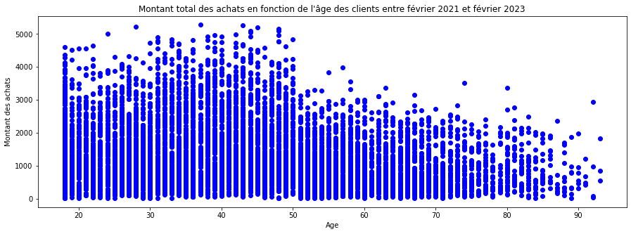

```python
memo=plt.plot(df_age_achats_cli['Age'],df_age_achats_cli['price'],"ob")
memo=plt.xlabel("Age")
memo=plt.ylabel("Montant des achats")
memo=plt.title("Montant total des achats en fonction de l'âge des clients entre février 2021 et février 2023")
memo=plt.show()
```

Détermination du coefficient de corrélation linéaire afin de définir l'intensité d'un lien linéaire entre les 2 variables et détermination du p_value  
On pose les hypothèses de départ :  
* H0 : Variables indépendantes si p-value > 5%  
* H1 : Variables non indépendantes si p-value < 5%

```python
coef_pearson,p_value = st.pearsonr(df_age_achats_cli['Age'], df_age_achats_cli['price'])
print("Coefficient de corrélation linéaire de Pearson = ",round(coef_pearson,3))
print("R^2 (coefficient de détermination) = ",round(coef_pearson**2,3))
print("p_value = ",p_value)
```

```
Coefficient de corrélation linéaire de Pearson =  -0.188
R^2 (coefficient de détermination) =  0.035
p_value =  1.7101053363389715e-69
```

Le coefficient de Pearson indique qu'il existe une corrélation négative entre l'âge du client et le montant des achats :  
* au plus le client est âgé, au plus le montant de ses achats est faible  
* au moins le client est âgé, au plus le montant de ses achats est important  
D'autre part, p_value < 5% et confirme qu'**on peut rejeter l'hypothèse H0 : les 2 variables sont probablement dépendantes l'une de l'autre.**  
On peut représenter la droite de régression linéaire associée avec la méthode des moindres carrés.

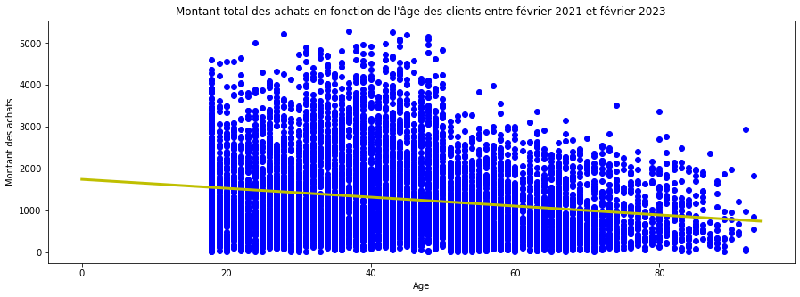

```
Equation de la droite : Y = -10.63 X +  1741.41
```

```python
Y = df_age_achats_cli['price']
X = df_age_achats_cli[['Age']]
X = X.copy()
X['intercept'] = 1.
result = sm.OLS(Y, X).fit() # OLS = Ordinary Least Square (Moindres Carrés Ordinaire)
a,b = result.params['Age'],result.params['intercept']
memo=plt.plot(df_age_achats_cli['Age'],df_age_achats_cli['price'],"ob")
memo=plt.plot(np.arange(95),[a*x+b for x in np.arange(95)],'y',linewidth=3)
memo=plt.xlabel("Age")
memo=plt.ylabel("Montant des achats")
memo=plt.title("Montant total des achats en fonction de l'âge des clients entre février 2021 et février 2023")
memo=plt.show()
print("Equation de la droite : Y =",round(a,2),"X + ",round(b,2))
```

### **Corrélation entre l'âge et le montant total des achats**

Il s'agit d'analyser la corrélation entre 2 variables quantitatives.  
Afin de définir la corrélation entre ces 2 types de variables, il est nécessaire de réaliser **un test de corrélation linéaire** avec :  
variable indépendante (ou explicative) = l'âge  
variable dépendante (ou expliquée) = le montant total des achats  
* On crée d'abord le dataframe qui servira à notre analyse :

```python
#Création dataframe âge clients-montant total des achats
df_corrige=df.copy()
df_corrige=df_corrige.loc[(df_corrige['client_id']!='c_1609')&(df_corrige['client_id']!='c_6714')&\
                          (df_corrige['client_id']!='c_3454')&(df_corrige['client_id']!='c_4958')]
df1=df_corrige.copy()
df_age_achats=df1.groupby('Age').sum().reset_index()
```

* Représentation du diagramme de dispersion :

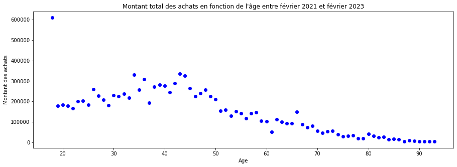

```python
memo=plt.plot(df_age_achats['Age'],df_age_achats['price'],"ob")
memo=plt.xlabel("Age")
memo=plt.ylabel("Montant des achats")
memo=plt.title("Montant total des achats en fonction de l'âge entre février 2021 et février 2023")
memo=plt.show()
```

Détermination du coefficient de corrélation linéaire afin de définir l'intensité d'un lien linéaire entre les 2 variables et détermination du p_value  
On pose les hypothèses de départ :  
* H0 : Variables indépendantes si p-value > 5%  
* H1 : Variables non indépendantes si p-value < 5%

```python
coef_pearson,p_value = st.pearsonr(df_age_achats['Age'], df_age_achats['price'])
print("Coefficient de corrélation linéaire de Pearson = ",round(coef_pearson,3))
print("R^2 (coefficient de détermination) = ",round(coef_pearson**2,3))
print("p_value = ",p_value)
```

```
Coefficient de corrélation linéaire de Pearson =  -0.831
R^2 (coefficient de détermination) =  0.69
p_value =  1.6783928183297813e-20
```

Il existe un lien statitique négatif fort entre l'âge du client et le montant des achats :  
* au plus le client est âgé, au plus le montant de ses achats est faible  
* au moins le client est âgé, au plus le montant de ses achats est important  
D'autre part, p_value < 5% alors **on peut rejeter l'hypothèse H0 et les 2 variables sont probablement dépendantes l'une de l'autre.**  
On peut représenter la droite de régression linéaire associée avec la méthode des moindres carrés.  
Cette droite pourra déterminer 69% de la distribution des points.

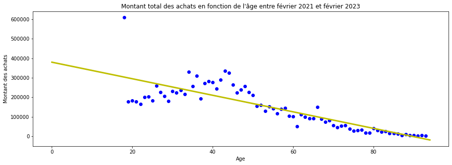

```
Equation de la droite : Y = -4242.46 X +  379834.29
```

```python
Y = df_age_achats['price']
X = df_age_achats[['Age']]
X = X.copy()
X['intercept'] = 1.
result = sm.OLS(Y, X).fit() # OLS = Ordinary Least Square (Moindres Carrés Ordinaire)
a,b = result.params['Age'],result.params['intercept']
memo=plt.plot(df_age_achats['Age'],df_age_achats['price'],"ob")
memo=plt.plot(np.arange(95),[a*x+b for x in np.arange(95)],'y',linewidth=3)
memo=plt.xlabel("Age")
memo=plt.ylabel("Montant des achats")
memo=plt.title("Montant total des achats en fonction de l'âge entre février 2021 et février 2023")
memo=plt.show()
print("Equation de la droite : Y =",round(a,2),"X + ",round(b,2))
```

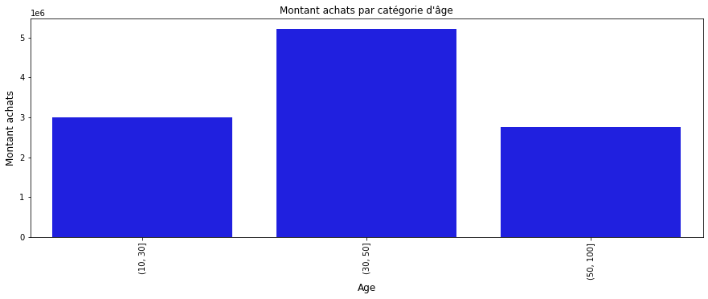

```python
#Agrégation variable âge en "catégorie âge"
df_age_achats['categorie_age']=pd.cut(df_age_achats['Age'],bins=[10,30,50,100])
#Affichage graphique
df3=df_age_achats.groupby(['categorie_age']).sum().reset_index()
mem=sns.barplot(x='categorie_age',y='price',data=df3,color='blue')
mem=plt.title("Montant achats par catégorie d'âge")
mem=plt.ylabel("Montant achats", fontsize=12)
mem=plt.xlabel("Age", fontsize=12)
memo=plt.xticks(rotation=90)
mem=plt.show()
```

### **Corrélation entre l'âge des clients et la fréquence d’achat**

Il s'agit là aussi d'analyser **la corrélation entre 2 variables quantitatives.**  
Afin de définir la corrélation entre ces 2 types de variables, il est nécessaire de réaliser **un test de corrélation linéaire avec :**  
variable indépendante (ou explicative) = l'âge  
variable dépendante (ou expliquée) = la fréquence d'achats  
* On crée d'abord le dataframe qui servira à notre analyse :

```python
#Création dataframe âge client-fréquence d'achats
df_corrige=df.copy().reset_index()
df_corrige=df_corrige.loc[(df_corrige['client_id']!='c_1609')&(df_corrige['client_id']!='c_6714')&\
                          (df_corrige['client_id']!='c_3454')&(df_corrige['client_id']!='c_4958')]
#On ne conserve qu'1 ligne par session_id donc 1 session_id = 1 achat
df2=df_corrige.drop_duplicates(subset = "session_id").copy()
df2['nb_achat'] = 1
df_age_freq_achats_cli=df2.groupby(['Age','client_id']).count().reset_index()
df_age_freq_achats_cli=df_age_freq_achats_cli[['Age','client_id','nb_achat']]
df_age_freq_achats_cli['freq_achats']=df_age_freq_achats_cli['nb_achat']/df_age_freq_achats_cli['nb_achat'].sum()
df_age_freq_achats_cli.head()
```

|  | Age | client_id | nb_achat | freq_achats |
| --- | --- | --- | --- | --- |
| 0 | 18 | c_1042 | 8 | 0.000025 |
| 1 | 18 | c_1046 | 15 | 0.000047 |
| 2 | 18 | c_1065 | 20 | 0.000063 |
| 3 | 18 | c_1088 | 11 | 0.000034 |
| 4 | 18 | c_109 | 5 | 0.000016 |

**A noter, dans ce cas de figure, l'âge est pondéré par le nombre de clients de cet âge.**

* Représentation du diagramme de dispersion :

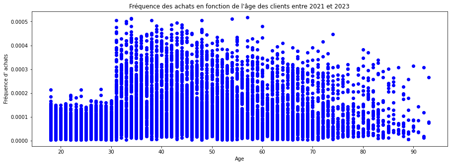

```python
memo=plt.plot(df_age_freq_achats_cli['Age'],df_age_freq_achats_cli['freq_achats'],"ob")
memo=plt.xlabel("Age")
memo=plt.ylabel("Fréquence d' achats")
memo=plt.title("Fréquence des achats en fonction de l'âge des clients entre 2021 et 2023")
memo=plt.show()
```

On va étudier l'évolution pour les - de 50 ans et les + de 50 ans

```python
#On crée les 2 dataframes - de 50 ans et + de 50 ans :
dfmoins50= df_age_freq_achats_cli.loc[df_age_freq_achats_cli['Age']<50]
dfplus50= df_age_freq_achats_cli.loc[df_age_freq_achats_cli['Age']>49]
```

Détermination du coefficient de corrélation linéaire afin de définir l'intensité d'un lien linéaire entre les 2 variables et détermination du p_value  
On pose les hypothèses de départ :  
* H0 : Variables indépendantes si p-value > 5%  
* H1 : Variables non indépendantes si p-value < 5%

```python
print("Analyse moins de 50 ans : \n")
coef_pearson,p_value = st.pearsonr(dfmoins50['Age'], dfmoins50['freq_achats'])
print("Coefficient de corrélation linéaire de Pearson = ",round(coef_pearson,3))
print("R^2 (coefficient de détermination) = ",round(coef_pearson**2,3))
print("p_value = ",p_value)

print("\nAnalyse plus de 50 ans : \n")
coef_pearson,p_value = st.pearsonr(dfplus50['Age'], dfplus50['freq_achats'])
print("Coefficient de corrélation linéaire de Pearson = ",round(coef_pearson,3))
print("R^2 (coefficient de détermination) = ",round(coef_pearson**2,3))
print("p_value = ",p_value)
```

```
Analyse moins de 50 ans :

Coefficient de corrélation linéaire de Pearson =  0.396
R^2 (coefficient de détermination) =  0.157
p_value =  2.787281947606434e-205

Analyse plus de 50 ans :

Coefficient de corrélation linéaire de Pearson =  -0.052
R^2 (coefficient de détermination) =  0.003
p_value =  0.0035491062359061065
```

**Pour les - de 50 ans**  
Le coefficient de Pearson est de 0,396 ce qui indique un lien statistique positif entre les variables. Au + le client est âgé, au + il achète.  
**Pour les plus de 50 ans**  
Le coefficient de Pearson est de -0,052 ce qui indique un lien statistique négatif entre les variables.  
Au + le client est âgé, au - il achète.  
Dans les 2 cas, la p_value < 5% et nous indique qu'**on peut rejeter l'hypothèse H0 et qu'il existe probablement une dépendance entre les 2 variables.**

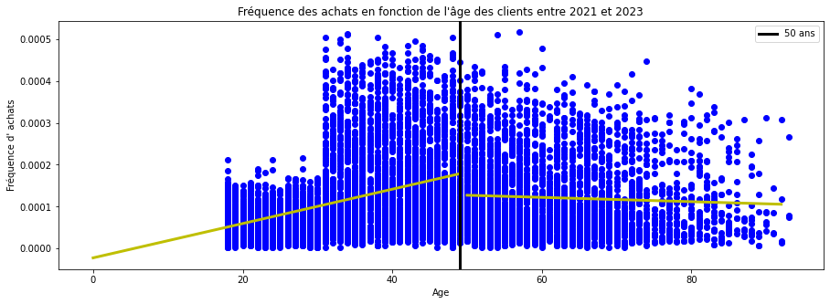

```
Equation de la droite pour les - de 50ans: Y = 4e-06 X +  -2e-05
Equation de la droite pour les + de 50ans: Y = -1e-06 X +  0.00015
```

```python
#Pour les - de 50 ans
Y = dfmoins50['freq_achats']
X = dfmoins50[['Age']]
X = X.copy()
X['intercept'] = 1.
result = sm.OLS(Y, X).fit() # OLS = Ordinary Least Square (Moindres Carrés Ordinaire)
a,b = result.params['Age'],result.params['intercept']

#Pour les + de 50 ans
Y1 = dfplus50['freq_achats']
X1 = dfplus50[['Age']]
X1 = X1.copy()
X1['intercept'] = 1.
result1 = sm.OLS(Y1, X1).fit() # OLS = Ordinary Least Square (Moindres Carrés Ordinaire)
a1,b1 = result1.params['Age'],result1.params['intercept']

memo=plt.plot(df_age_freq_achats_cli['Age'],df_age_freq_achats_cli['freq_achats'],"ob")
memo=plt.plot(np.arange(50),[a*x+b for x in np.arange(50)],'y',linewidth=3)
memo=plt.plot(range(50,93),[a1*x+b1 for x in range(50,93)],'y',linewidth=3)
memo=plt.axvline(x=df_age_freq_achats_cli.index[49],color='black',linewidth=3, label="50 ans")
memo=plt.xlabel("Age")
memo=plt.ylabel("Fréquence d' achats")
memo=plt.legend(loc = 'best')
memo=plt.title("Fréquence des achats en fonction de l'âge des clients entre 2021 et 2023")
memo=plt.show()
print("Equation de la droite pour les - de 50ans: Y =",round(a,6),"X + ",round(b,5))
print("Equation de la droite pour les + de 50ans: Y =",round(a1,6),"X + ",round(b1,5))
```

### **Corrélation entre l'âge et la fréquence d’achat**

Il s'agit là aussi d'analyser la corrélation entre **2 variables quantitatives.**  
Afin de définir la corrélation entre ces 2 types de variables, il est nécessaire de réaliser un **test de corrélation linéaire** avec :  
variable indépendante (ou explicative) = l'âge  
variable dépendante (ou expliquée) = la fréquence d'achats  
* On crée d'abord le dataframe qui servira à notre analyse :

```python
#Création dataframe âge client-fréquence d'achats
df_corrige=df.copy().reset_index()
df_corrige=df_corrige.loc[(df_corrige['client_id']!='c_1609')&(df_corrige['client_id']!='c_6714')&\
                          (df_corrige['client_id']!='c_3454')&(df_corrige['client_id']!='c_4958')]
#On ne conserve qu'1 ligne par session_id donc 1 session_id = 1 achat
df2=df_corrige.drop_duplicates(subset = "session_id").copy()
df2['nb_achat'] = 1
df_age_freq_achats=df2.groupby('Age').count().reset_index()
df_age_freq_achats=df_age_freq_achats[['Age','nb_achat']]
df_age_freq_achats['freq_achats']=df_age_freq_achats['nb_achat']/df_age_freq_achats['nb_achat'].sum()
df_age_freq_achats.head()
```

|  | Age | nb_achat | freq_achats |
| --- | --- | --- | --- |
| 0 | 18 | 8594 | 0.026920 |
| 1 | 19 | 2567 | 0.008041 |
| 2 | 20 | 2604 | 0.008157 |
| 3 | 21 | 2431 | 0.007615 |
| 4 | 22 | 2421 | 0.007584 |

* Représentation du diagramme de dispersion :

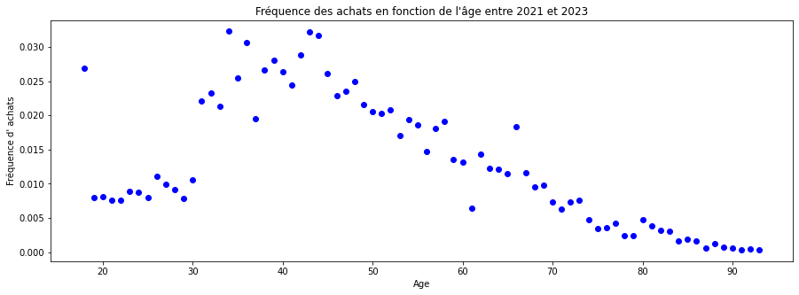

```python
memo=plt.plot(df_age_freq_achats['Age'],df_age_freq_achats['freq_achats'],"ob")
memo=plt.xlabel("Age")
memo=plt.ylabel("Fréquence d' achats")
memo=plt.title("Fréquence des achats en fonction de l'âge entre 2021 et 2023")
memo=plt.show()
```

* Détermination du coefficient de corrélation linéaire afin de définir l'intensité d'un lien linéaire entre les 2 variables et détermination du p_value  
On pose les hypothèses de départ :  
* H0 : Variables indépendantes si p-value > 5%  
* H1 : Variables non indépendantes si p-value < 5%

```python
coef_pearson,p_value = st.pearsonr(df_age_freq_achats['Age'], df_age_freq_achats['freq_achats'])
print("Coefficient de corrélation linéaire de Pearson = ",round(coef_pearson,3))
print("R^2 (coefficient de détermination) = ",round(coef_pearson**2,3))
print("p_value = ",p_value)
```

```
Coefficient de corrélation linéaire de Pearson =  -0.601
R^2 (coefficient de détermination) =  0.361
p_value =  9.30562727225924e-09
```

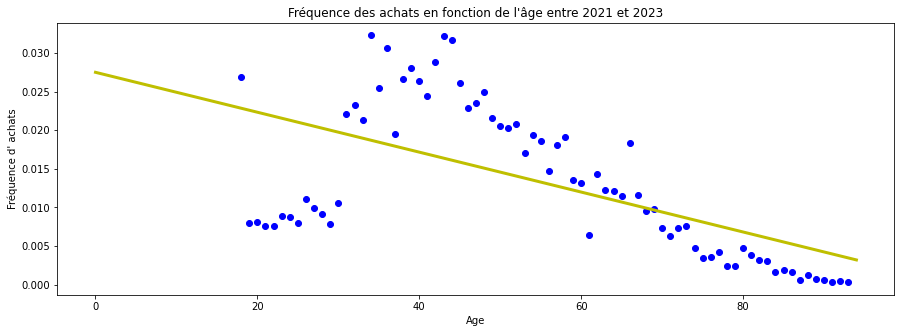

```
Equation de la droite : Y = -0.00026 X +  0.03
```

```python
Y = df_age_freq_achats['freq_achats']
X = df_age_freq_achats[['Age']]
X = X.copy()
X['intercept'] = 1.
result = sm.OLS(Y, X).fit() # OLS = Ordinary Least Square (Moindres Carrés Ordinaire)
a,b = result.params['Age'],result.params['intercept']
memo=plt.plot(df_age_freq_achats['Age'],df_age_freq_achats['freq_achats'],"ob")
memo=plt.plot(np.arange(95),[a*x+b for x in np.arange(95)],'y',linewidth=3)
memo=plt.xlabel("Age")
memo=plt.ylabel("Fréquence d' achats")
memo=plt.title("Fréquence des achats en fonction de l'âge entre 2021 et 2023")
memo=plt.show()
print("Equation de la droite : Y =",round(a,5),"X + ",round(b,2))
```

Il existe un lien statitique négatif entre l'âge du client et la fréquence d'achats  
D'autre part, p_value < 5% alors **on peut rejeter l'hypothèse H0 et les 2 variables sont probablement dépendantes l'une de l'autre.**  
Si on agrège la variable âge en classe d'âge, on obtient :

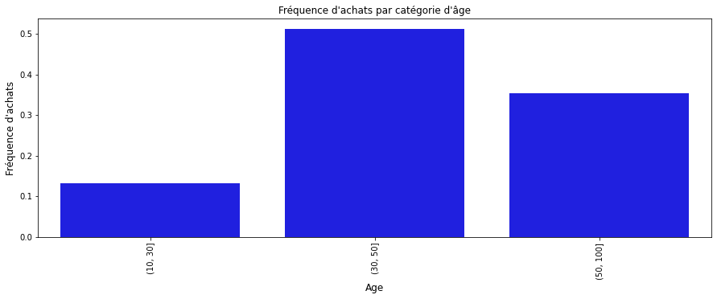

```python
#Agrégation variable âge en "catégorie âge"
df_age_freq_achats['categorie_age']=pd.cut(df_age_freq_achats['Age'],bins=[10,30,50,100])
#Affichage graphique
df3=df_age_freq_achats.groupby(['categorie_age']).sum().reset_index()
mem=sns.barplot(x='categorie_age',y='freq_achats',data=df3,color='blue')
mem=plt.title("Fréquence d'achats par catégorie d'âge")
mem=plt.ylabel("Fréquence d'achats", fontsize=12)
mem=plt.xlabel("Age", fontsize=12)
memo=plt.xticks(rotation=90)
mem=plt.show()
```

* On voit clairement que ce sont les 30-50 ans qui font le plus d'achats.  
* Ensuite, au plus l'âge augmente, au moins il y a d'achats.  
* Les - de 30 ans achètent des produits plus chers mais font moins d'achats.

### **Corrélation entre l'âge des clients et la taille du panier moyen**

Il s'agit là aussi d'analyser la corrélation **entre 2 variables quantitatives**.  
Afin de définir la corrélation entre ces 2 types de variables, il est nécessaire de réaliser un test de corrélation linéaire avec :  
variable indépendante (ou explicative) = l'âge du client  
variable dépendante (ou expliquée) = la taille du panier moyen  
* On crée d'abord le dataframe qui servira à notre analyse :

```python
df_temp = df_corrige.groupby(['Age', 'client_id','session_id']).count().reset_index()
df_age_client_taille_panier=df_temp.groupby(['Age','client_id']).mean().reset_index()
```

* Représentation du diagramme de dispersion :

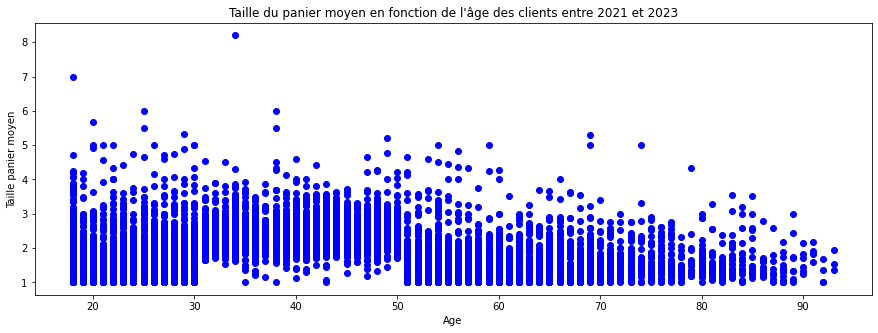

```python
memo=plt.plot(df_age_client_taille_panier['Age'],df_age_client_taille_panier['id_prod'],"ob")
memo=plt.xlabel("Age")
memo=plt.ylabel("Taille panier moyen")
memo=plt.title("Taille du panier moyen en fonction de l'âge des clients entre 2021 et 2023")
memo=plt.show()
```

**A noter, dans ce cas de figure, l'âge est pondéré par le nombre de clients de cet âge.**

* Détermination du coefficient de corrélation linéaire afin de définir l'intensité d'un lien linéaire entre les 2 variables et détermination du p_value  
On pose les hypothèses de départ :  
* H0 : Variables indépendantes si p-value > 5%  
* H1 : Variables non indépendantes si p-value < 5%

```python
coef_pearson,p_value = st.pearsonr(df_age_client_taille_panier['Age'], df_age_client_taille_panier['id_prod'])
print("Coefficient de corrélation linéaire de Pearson = ",round(coef_pearson,3))
print("R^2 (coefficient de détermination) = ",round(coef_pearson**2,3))
print("p_value = ",p_value)
```

```
Coefficient de corrélation linéaire de Pearson =  -0.213
R^2 (coefficient de détermination) =  0.045
p_value =  1.2372377168355913e-88
```

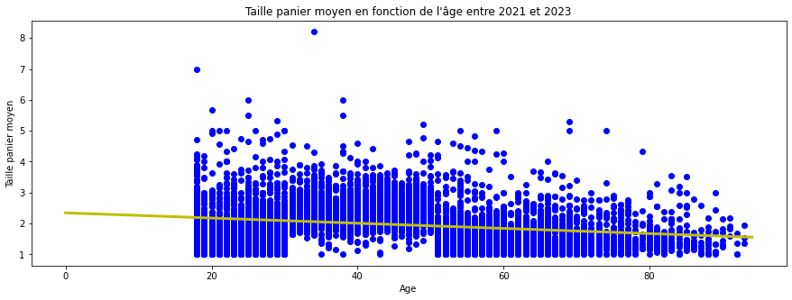

```
Equation de la droite : Y = -0.00837 X +  2.35
```

```python
Y = df_age_client_taille_panier['id_prod']
X = df_age_client_taille_panier[['Age']]
X = X.copy()
X['intercept'] = 1.
result = sm.OLS(Y, X).fit() # OLS = Ordinary Least Square (Moindres Carrés Ordinaire)
a,b = result.params['Age'],result.params['intercept']
memo=plt.plot(df_age_client_taille_panier['Age'],df_age_client_taille_panier['id_prod'],"ob")
memo=plt.plot(np.arange(95),[a*x+b for x in np.arange(95)],'y',linewidth=3)
memo=plt.xlabel("Age")
memo=plt.ylabel("Taille panier moyen")
memo=plt.title("Taille panier moyen en fonction de l'âge entre 2021 et 2023")
memo=plt.show()
print("Equation de la droite : Y =",round(a,5),"X + ",round(b,2))
```

Il existe un **lien statitique négatif entre l'âge du client et la taille du panier moyen.**  
D'autre part, la p_value < 5% alors **on peut rejeter l'hypothèse H0 : les 2 variables sont probablement dépendantes l'une de l'autre.** On voit sur le graphique la présence de 3 groupes distincts de client :  
les - de 30 ans (une taille de panier moyen)  
entre 30 et 50 ans (la plus forte taille de panier moyen)  
les + de 50 ans (la plus faible taille de panier moyen)

### **Corrélation entre l'âge et la taille du panier moyen**

Il s'agit là aussi d'analyser la corrélation **entre 2 variables quantitatives.**  
Afin de définir la corrélation entre ces 2 types de variables, il est nécessaire de réaliser un test de corrélation linéaire avec :  
variable indépendante (ou explicative) = l'âge  
variable dépendante (ou expliquée) = la taille du panier moyen  
* On crée d'abord le dataframe qui servira à notre analyse :

```python
df_temp = df_corrige.groupby(['Age', 'session_id']).count().reset_index()
df_client_taille_panier=df_temp.groupby('Age').mean().reset_index()
```

* Représentation du diagramme de dispersion :

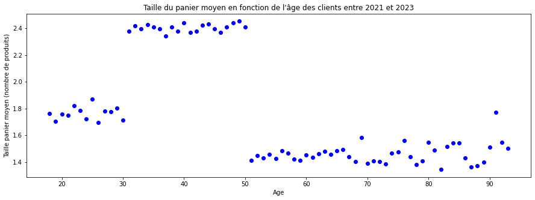

```python
memo=plt.plot(df_client_taille_panier['Age'],df_client_taille_panier['id_prod'],"ob")
memo=plt.xlabel("Age")
memo=plt.ylabel("Taille panier moyen (nombre de produits)")
memo=plt.title("Taille du panier moyen en fonction de l'âge des clients entre 2021 et 2023")
memo=plt.show()
```

* Détermination du coefficient de corrélation linéaire afin de définir l'intensité d'un lien linéaire entre les 2 variables et détermination du p_value  
On pose les hypothèses de départ :  
* H0 : Variables indépendantes si p-value > 5%  
* H1 : Variables non indépendantes si p-value < 5%

```python
coef_pearson,p_value = st.pearsonr(df_client_taille_panier['Age'], df_client_taille_panier['id_prod'])
print("Coefficient de corrélation linéaire de Pearson = ",round(coef_pearson,3))
print("R^2 (coefficient de détermination) = ",round(coef_pearson**2,3))
print("p_value = ",p_value)
```

```
Coefficient de corrélation linéaire de Pearson =  -0.588
R^2 (coefficient de détermination) =  0.346
p_value =  2.3543575216079563e-08
```

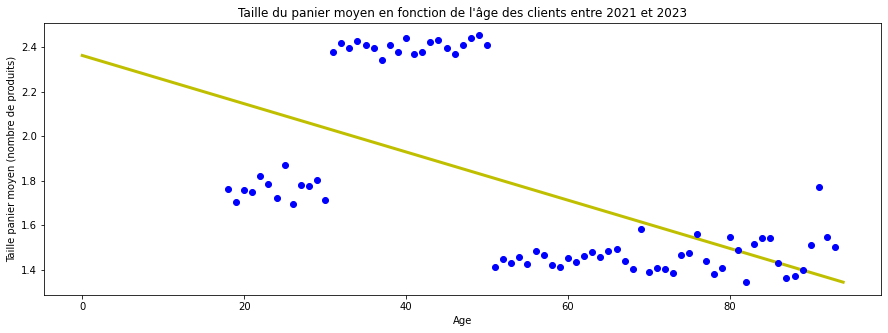

```python
Y = df_client_taille_panier['id_prod']
X = df_client_taille_panier[['Age']]
X = X.copy()
X['intercept'] = 1.
result = sm.OLS(Y, X).fit() # OLS = Ordinary Least Square (Moindres Carrés Ordinaire)
a,b = result.params['Age'],result.params['intercept']
memo=plt.plot(np.arange(95),[a*x+b for x in np.arange(95)],'y',linewidth=3)
memo=plt.plot(df_client_taille_panier['Age'],df_client_taille_panier['id_prod'],"ob")
memo=plt.xlabel("Age")
memo=plt.ylabel("Taille panier moyen (nombre de produits)")
memo=plt.title("Taille du panier moyen en fonction de l'âge des clients entre 2021 et 2023")
memo=plt.show()
```

Il existe un **lien statitique négatif entre l'âge du client et la taille du panier moyen**  
D'autre part, p_value < 5% alors **on peut rejeter l'hypothèse H0 : les 2 variables sont probablement dépendantes l'une de l'autre.**  
On voit sur le graphique là-aussi la présence de 3 groupes distincts de client :  
* les - de 30 ans (une taille de panier moyen)  
* entre 30 et 50 ans (la plus forte taille de panier moyen)  
* les + de 50 ans (la plus faible taille de panier moyen)  
La présence des 3 groupes est aussi très flagrante avec une réprésentation par boxplot

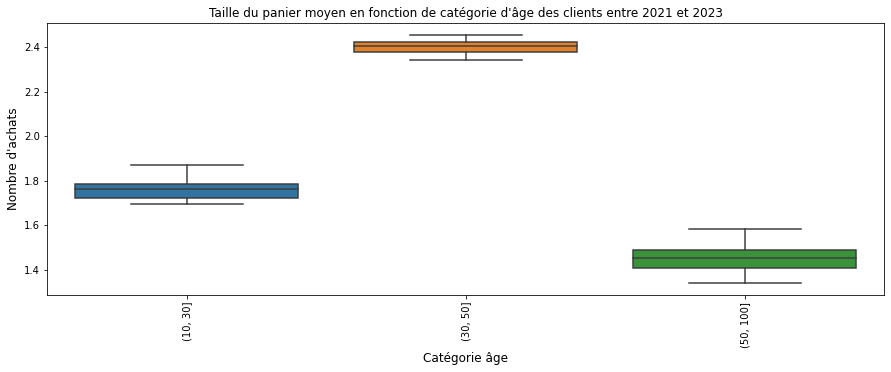

```python
#Agrégation variable âge en "catégorie âge"
df_client_taille_panier['categorie_age']=pd.cut(df_client_taille_panier['Age'],bins=[10,30,50,100])
memo=sns.boxplot(x='categorie_age', y='id_prod', data=df_client_taille_panier,showfliers=False)
memo=plt.xticks(rotation=90)
mem=plt.ylabel("Nombre d'achats", fontsize=12)
mem=plt.xlabel("Catégorie âge", fontsize=12)
memo=plt.title("Taille du panier moyen en fonction de catégorie d'âge des clients entre 2021 et 2023")
plt.show()
```

* Les 30-50 ans : ce sont ceux qui achètent le plus d'articles  
* Les + de 50 ans : ce sont ceux qui achètent le moins d'articles  
* Les - de 30 ans : ils ont une taille de panier intérmédiaire

Suite du projet : Analyses bivariées (suite)